# Kolomytseva_hw4

2024-03-18

# ДЗ 4. Расчет описательных статистик

# Коломыцева Анна

Загрузка библиотек

```r
library(tidyverse)
```

## Задание 1

Рассмотрим следующую статистическую гипотезу:

Проводят некоторое исследование пациентов с артериальной гипертензией. Предположим, что внедрение нового препарата в среднем лучше снижает их давление по сравнению со стандартной терапией.

Задайте seed для воспроизводимости результатов. Задайте размер выборки. Задайте значение среднего артериального (систолического) давления до приема нового препарата и после.

```r
set.seed(757)
sample_size <- 30
BP_before <- rnorm(n = sample_size, mean = 145, sd = 5)
BP_after <- rnorm(n = sample_size, mean = 120, sd = 5)
```

- Сформулируйте нулевую и альтернативную гипотезы.
- Определите уровень значимости.

```r
H0 <- "нет значимой разницы между давлением до приема препарата и после"
Ha <- "давление после приема препарата значимо меньше, чем до"
alpha <- 0.05
```

- Выберите статистический тест для проверки гипотезы и аргументируйте свой выбор.

Требуется сравнить две выборки непрерывных нормально распределеннных данных, дисперсии признаков в выборках равны. Для этого предназначен двухвыборочный t-тест.

- Определите наблюдаемое значение статистики, а также критическое значение статистики.

```r
res <- t.test(BP_before, BP_after)
sprintf("наблюдаемое значение t-статистики = %.3f", res$statistic)
```

```
## [1] "наблюдаемое значение t-статистики = 22.317"
```

```r
t_crit <- qt(p=alpha, df=res$parameter, lower.tail=FALSE)
sprintf("критическое значение t-статистики = %.3f", t_crit)
```

```
## [1] "критическое значение t-статистики = 1.672"
```

```r
sprintf("P-value = %.2f", res$p.value)
```

```
## [1] "P-value = 0.00"
```

```r
if (res$p.value < alpha){
  print(Ha)
}else{
  print(H0)
}
```

```
## [1] "давление после приема препарата значимо меньше, чем до"
```

- Оцените и прокомментируйте статистическую значимость.

Наблюдаемое значение t-статистики значительно превышает критическое значение на заданном уровне значимости. P-значение намного меньше стандартного порога $\alpha=0.05$, что указывает на статистическую значимость результата. Таким образом отвергаем нулевую гипотезу, принимаем альтернативную: давление после приема препарата значимо меньше, чем до.

## Задание 2

Рассмотрим следующую статистическую гипотезу:

Существует некоторая связь между курением и развитием рака легких. Пусть у курящих людей вероятность заболеть раком легких составляет 0.8, а у некурящих — 0.2 Рассмотрите два случая: для выборки размером 100 и выборки размером 30. Сгенерируйте данные по курению с помощью функции rep(), пусть отношение числа курящих к некурящим в каждой выборке составляет 1:1.

```r
sample_size1 <- 100
sample_size2 <- 30
set.seed(757)

generate_dataset <- function(n) {
  smokers <- rep(c(TRUE, FALSE), each = n/2)
  # Генерация случаев рака легких для курящих
  cancer_in_smokers <- sample(c(TRUE, FALSE), size = n/2,
                              prob = c(0.8, 0.2), replace = TRUE)

  # Генерация случаев рака легких для некурящих
  cancer_in_nonsmokers <- sample(c(TRUE, FALSE), size = n/2,
                                 prob = c(0.2, 0.8), replace = TRUE)

  # Сборка датасета
  return(data.frame(
    smoker = smokers,
    lung_cancer = c(cancer_in_smokers, cancer_in_nonsmokers)))
}

dataset1 <- generate_dataset(sample_size1)
dataset2 <- generate_dataset(sample_size2)
```

- Сформулируйте нулевую и альтернативную гипотезы.
- Определите уровень значимости.

```r
H0 <- "нет значимой связи между курением и развитием рака легких, заболеваемоть одинакова у курящих и некурящих"
Ha <- "есть статистически значимая связь между курением и развитием рака легких"
alpha <- 0.05
```

- Выберите статистический тест для проверки гипотезы и аргументируйте свой выбор.

Значимость различий между фактическим (выявленным в результате исследования) количеством качественных характеристик выборки, попадающих в каждую категорию, и теоретическим количеством (по нулевой гипотезе) позволяют оценить критерий хи-квадрат и точный критерий Фишера. Однако критерий хи-квадрат исправно работает только в случае, когда количество всех частот превышает 50, а минимальное ожидаемое значение для каждой группы не меньше 5 (на практике часто используют порог в 10 значений). Тест Фишера — точный, и поэтому может использоваться независимо от особенностей выборки. Он позволяет получать более аккуратный анализ для маленьких выборок или данных, которые редки.

С учетом рамеров выборок, для первой используем критерий хи-квадрат, а для второй - точный критерий Фишера.

- Определите наблюдаемое значение статистики, а также критическое значение статистики.

```r
# выборка 1
# Создание таблицы сопряженности
table_data1 <- table(dataset1$smoker, dataset1$lung_cancer)
dimnames(table_data1) <- list(
  Smoking_Status = c("Non-Smoker", "Smoker"),
  Lung_Cancer = c("No", "Yes"))
table_data1
```

```
##               Lung_Cancer
## Smoking_Status No Yes
##     Non-Smoker 39  11
##     Smoker     10  40
```

```r
res_chi <- chisq.test(table_data1)
sprintf("наблюдаемое значение статистики хи-квадрат = %.3f", res_chi$statistic)
```

```
## [1] "наблюдаемое значение статистики хи-квадрат = 31.373"
```

```r
t_crit <- qchisq(p=alpha, df=res_chi$parameter, lower.tail=FALSE)
sprintf("критическое значение статистики хи-квадрат = %.3f", t_crit)
```

```
## [1] "критическое значение статистики хи-квадрат = 3.841"
```

```r
sprintf("P-value критерия хи-квадрат = %.3f", res_chi$p.value)
```

```
## [1] "P-value критерия хи-квадрат = 0.000"
```

```r
if (res_chi$p.value < alpha){
  print(Ha)
}else{
  print(H0)
}
```

```
## [1] "есть статистически значимая связь между курением и развитием рака легких"
```

```r
# выборка 2
table_data2 <- table(dataset2$smoker, dataset2$lung_cancer)
dimnames(table_data2) <- list(
  Smoking_Status = c("Non-Smoker", "Smoker"),
  Lung_Cancer = c("No", "Yes"))
table_data2
```

```
##               Lung_Cancer
## Smoking_Status No Yes
##     Non-Smoker 13   2
##     Smoker      2  13
```

```r
res_fisher <- fisher.test(table_data2)
sprintf("P-value теста Фишера = %.3f", res_fisher$p.value)
```

```
## [1] "P-value теста Фишера = 0.000"
```

```r
if (res_fisher$p.value < alpha){
  print(Ha)
}else{
  print(H0)
}
```

```
## [1] "есть статистически значимая связь между курением и развитием рака легких"
```

- Оцените и прокомментируйте статистическую значимость.

Для первой выборки размером 100 тест хи-квадрат показал значение статистики большее, чем критисекое, а также значение p близко к 0 (много меньше $\alpha=0.05$), следовательно результаты теста статистически значимы: есть статистически значимая связь между курением и развитием рака легких.

Для второй выборки размером 30 использовали тест Фишера. В отличие от теста Хи-квадрат, точный тест Фишера не содержит статистики тестирования для отчета. Вместо этого выводим p-значение теста: оно много меньше $\alpha=0.05$, что говорит о наличии статистической значимости. Можно также обратить внимание на отношение шансов и его 95% доверительный интервал:

```r
res_fisher$estimate
```

```
## odds ratio
##   34.12385
```

```r
res_fisher$conf.int[1:2]
```

```
## [1]   3.982059 562.861006
```

Число 1 не входит в пределы этого отношения, это подтверждает, альтернативную гипотезу: есть статистически значимая связь между курением и развитием рака легких.

## Задание 3

Рассмотрим следующую статистическую гипотезу:

Применение нового метода лечения синдрома раздраженного кишечника значимо меняет уровень болевых симптомов по сравнению с группой, прошедшей лечение диетотерапией.

Исследователь избегает любых допущений, кроме того, что выборки независимы и имеют одинаковое распределение.

```r
set.seed(757)

new <- runif(n=30, min=0, max=4)
diets <- runif(n=30, min=2, max=6)
```

- Сформулируйте нулевую и альтернативную гипотезы.
- Определите уровень значимости.

```r
H0 <- "нет значимой разницы в уровне болевых симптомов между новым методом и диетотерапией"
Ha <- "есть статистически значимая разница: новый метод лечения значимо меняет уровень болевых симптомов по сравнению с диетотерапией"
alpha <- 0.05
```

- Выберите статистический тест для проверки гипотезы и аргументируйте свой выбор.

В исследовании нет допущений о нормальности распределения. Две выборки независимы и имеют одинаковое распределение. Следовательно, для провеки статистической значимости подойдет тест Манна-Уитни. Он считается непараметрическим эквивалентом двухвыборочного независимого t-критерия.

- Определите наблюдаемое значение статистики, а также критическое значение статистики.

```r
res <- wilcox.test(new, diets, alternative="less")
sprintf("наблюдаемое значение U-статистики = %.f", res$statistic)
```

```
## [1] "наблюдаемое значение U-статистики = 98"
```

```r
W_crit <- 338 # для выборок размерами по 30 и alpha=0.05
# https://koi.tspu.ru/biostat/Mann-Whitney%20statistics.pdf
sprintf("критическое значение U-статистики = %.f", W_crit)
```

```
## [1] "критическое значение U-статистики = 338"
```

```r
sprintf("P-value критерия хи-квадрат = %.3f", res$p.value)
```

```
## [1] "P-value критерия хи-квадрат = 0.000"
```

```r
if (res$p.value < alpha){
  print(Ha)
}else{
  print(H0)
}
```

```
## [1] "есть статистически значимая разница: новый метод лечения значимо меняет уровень болевых симптомов по сравнению с диетотерапией"
```

- Оцените и прокомментируйте статистическую значимость.

Поскольку тестовая статистика меньше критического значения, а p-значение много меньше $\alpha=0.05$, то отвергаем нулевую гипотезу. Делаем вывод, что есть статистически значимая разница: новый метод лечения значимо меняет уровень болевых симптомов по сравнению с диетотерапией.

## Задание 4

Рассмотрим следующую гипотезу:

Проводится исследование, в котором исследуются три противоопухолевые препарата A, B плацебо (0) на трех группах мышей. В каждой из трех групп по 10 мышей. Оценивается размер опухоли у мыши.

Сгенерируем датасет:

```r
tumor <- tibble(
  therapy = c(rep("0", 10), rep("A", 10), rep("B", 10)),
  value = c(rep(3213, 10), rep(2687, 10), rep(2423, 10))
) %>%
  mutate(therapy = factor(therapy, levels = c("0", "A", "B")))
tumor$value <- tumor$value + rnorm(30, 0, 760)
tumor
```

```
## # A tibble: 30 × 2
##    therapy value
##    <fct>   <dbl>
##  1 0       3671.
##  2 0       2195.
##  3 0       4493.
##  4 0       3480.
##  5 0       4458.
##  6 0       2884.
##  7 0       3224.
##  8 0       2416.
##  9 0       3984.
## 10 0       2767.
## # ℹ 20 more rows
```

Построим на одном графике три boxplot:

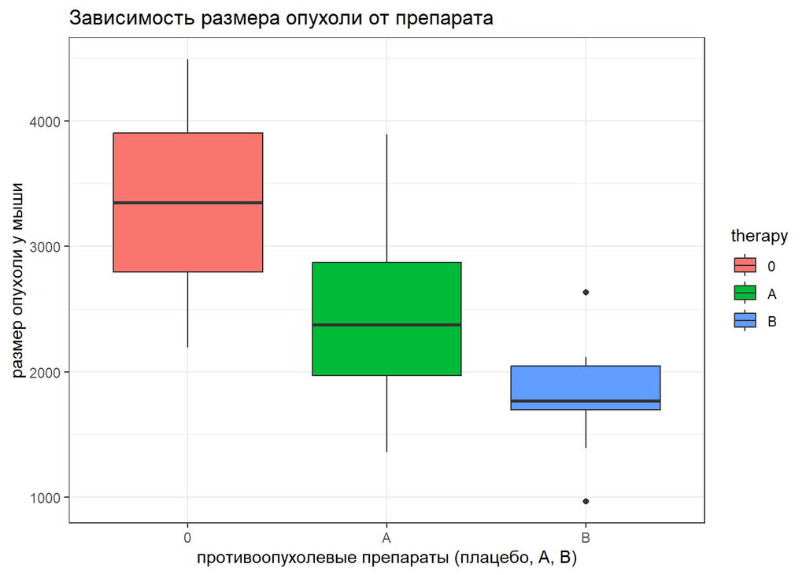

```r
tumor %>%
  ggplot(aes(therapy, value, fill=therapy)) +
  geom_boxplot() +
  theme_bw() +
  labs(title = "Зависимость размера опухоли от препарата",
      x = "противоопухолевые препараты (плацебо, A, B)",
      y = "размер опухоли у мыши")
```

- Сформулируйте нулевую и альтернативную гипотезы. - Определите уровень значимости.

```r
H0 <- "нет значимой разницы в размере опухоли между противоопухолевыми препаратами (плацебо, A, B)"
Ha <- "есть статистически значимая разница между противоопухолевыми препаратами (плацебо, A, B)"
alpha <- 0.05
```

- Проведите дисперсионный анализ, чтобы выяснить, есть ли разница между размером опухоли во всех группах. Прокомментируйте получившийся результат.

```r
anova <- aov(value ~ therapy, data = tumor)
summary(anova)
```

```
##             Df   Sum Sq Mean Sq F value  Pr(>F)
## therapy      2 12106686 6053343    12.7 0.00013 ***
## Residuals   27 12869824  476660
## ---
## Signif. codes:  0 '***' 0.001 '**' 0.01 '*' 0.05 '.' 0.1 ' ' 1
```

P-value по результатам дисперсионного анализа меньше $\alpha=0.05$, поэтому можно сказать, что есть значимая разница между противоопухолевыми препаратами (плацебо, A, B). Для уточнения какие именно группы различаются нужно провести попарные сравнения.

- С помощью функции TukeyHSD() проведите попарные сравнения, используя критерий Тьюки. Прокомментируйте полученные результаты.

```r
TukeyHSD(anova)
```

```
##   Tukey multiple comparisons of means
##     95% family-wise confidence level
##
## Fit: aov(formula = value ~ therapy, data = tumor)
##
## $therapy
##           diff       lwr       upr     p adj
## A-0  -935.5106 -1701.053 -169.9684 0.0142973
## B-0 -1544.6108 -2310.153 -779.0686 0.0000874
## B-A  -609.1002 -1374.642  156.4420 0.1383722
```

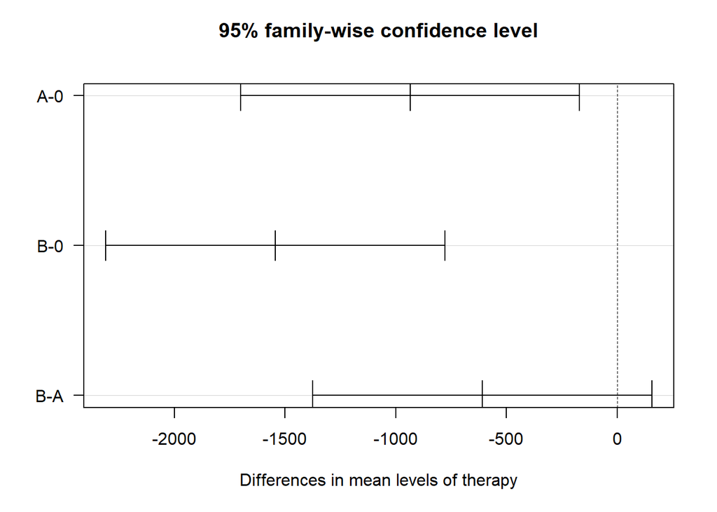

```r
# построим доверительные интервалы
fig <- plot(TukeyHSD(anova), las = 1)
```

По результатам прарных сравнений можно сказать, что есть значимая разница между препаратом А и плацебо и между B и плацебо, так как знаяение 0 не входит в доверителные интарвалы разности размеров опухоли для этих пар, а p-значение меньше $\alpha=0.05$.

Сравнение препаратов A и B с помощью критерия Тьюки показало, что доверительный интервал разности размеров опухоли включает 0, а p-значение превышает уровень значимости 0.05, то есть не можем отвергнуть нулевую гипотезу: нет значимой разницы в размере опухоли между противоопухолевыми препаратами A и B.